# Fundamentals of Long-Term Actuarial Modeling

ExaminationAid® Series

# §1: Introduction

## §1.1: Abstract

This research proposal, titled “Fundamentals of Long-Term Actuarial Modeling,” aims to integrate traditional actuarial practices with modern data science techniques through the application of object-oriented programming (OOP) principles in R. Inspired by insights from the Long-Term Actuarial Mathematics (LTAM) course and extensive professional experience in data science, this project presents a practical application of OOP in actuarial science. The proposal will illustrate how leveraging OOP concepts such as classes, objects, and inheritance can transform actuarial modeling by enhancing the modularity, reusability, and scalability of models.

Focusing on practical implementations in R, the proposal will use actuarial concepts from FAM-L to explain key programming principles like functions, algorithms, and plotting. The research demonstrates how to develop sophisticated data products that efficiently handle complex data sets, providing an alternative to traditional methods such as Excel tables. This approach serves as a foundation for developing innovative educational and professional tools, contributing to the Actuarial Science CRAN community, and leading to the eventual creation of comprehensive exam aid dashboards tailor made for the actuarial science industry and participants.

The findings and methodologies will be detailed in the succeeding sections of the proposal, showcasing real-world examples, case studies, and the practical application of OOP techniques in actuarial projects. This research ultimately aims to enhance actuarial workflows and foster greater collaboration within actuarial teams.

## §1.2: Content Overview

### §1.2.1 FAM-L Content

This proposal delves into the essential relationships between survival models, life tables, insurance benefits, annuities, and profitability, following a progression that mirrors the structure of “Actuarial Mathematics for Life Contingent Risks.”

- **Chapter 2**: Survival Models Survival models form the foundational basis for actuarial science, describing the distribution of time until events such as death. These models employ functions like the survival function and hazard function, which are crucial for understanding mortality trends. This understanding is essential for predicting lifespans and informing the design of life-contingent products.
- **Chapter 3**: Life Tables Life tables, derived from survival models, provide empirical data on mortality rates and survival probabilities at various ages. They are indispensable tools for actuaries, offering critical insights that inform the creation and pricing of insurance policies and annuities by illustrating the likelihood of survival across different age groups.
- **Chapter 4**: Insurance Benefits Insurance benefits are calculated by integrating survival probabilities to ensure adequate coverage. These benefits are designed based on the empirical data from life tables, ensuring that payouts are financially viable and meet the needs of policyholders. Accurate determination of present values for future payouts is crucial for the sustainability of insurance products.
- **Chapter 5**: Annuities Annuities provide regular payments over the lifetime of the annuitant and rely heavily on survival models and life tables for valuation. Different types of annuities (immediate, deferred, fixed, and variable) each require precise calculation of expected present values to ensure they provide sufficient income streams while being financially sustainable.
- **Chapter 6**: Profitability (Policy Values) Profitability in insurance products is assessed through policy values, which are the present values of future cash flows, including premiums and benefits. Actuarial models use survival probabilities, discount rates, and expense assumptions to determine these values. A profitable policy ensures that the present value of premiums surpasses the present value of benefits and expenses, thus ensuring the insurer’s financial health.

The progression from survival models to profitability illustrates the integrated nature of actuarial science. Each chapter builds on the previous, from understanding mortality trends and using this knowledge to design viable insurance products, to ultimately ensuring these products are profitable. This comprehensive approach ensures the development of robust insurance and financial products that meet individual needs and support the financial stability of insurance companies.

### §1.2.2 R-Programming Content

To achieve the goals outlined in the abstract and the overview, this proposal employs a variety of R programming techniques, catering to users of all skill levels—from novices to experts. These techniques demonstrate how R can be effectively utilized in professional environments to handle a range of actuarial tasks and situations.

#### §1.2.2.1 Novice and Intermediate Users

- **Plotting with ggplot2**: This powerful visualization package allows users to create complex and informative plots. Novices can start with basic plots, while intermediates can explore advanced customization and data visualization techniques, making it easier to communicate insights from actuarial data effectively.
- **Data-Frame Manipulation with dplyr and tidyverse**: These packages streamline data manipulation, enabling users to filter, arrange, and summarize data efficiently. Novices will learn the basics of data manipulation, and intermediates can leverage these tools for more sophisticated data wrangling tasks, essential for preparing actuarial data sets for analysis.
- **Algorithms with if-else Statements**: Basic conditional logic using if-else statements allows users to implement simple decision-making processes in their code. This foundational programming concept helps in automating repetitive tasks and is crucial for actuarial calculations and data analysis.

#### §1.2.2.2 Intermediate and Advanced Users

- **Algorithms with for-loop Statements**: For-loop statements enable the execution of repetitive tasks over a sequence of elements. Intermediate users will learn to iterate over data sets, performing complex calculations, and advanced users can optimize these loops for efficiency, crucial for handling large actuarial data sets.
- **Functional Programming with sapply**: The sapply function applies a function to each element of a list or vector, simplifying code and making it more readable. This concept introduces functional programming principles, which are beneficial for performing repetitive actuarial computations and data transformations.
- **Object-Oriented Programming with S4 Class Objects**: S4 class objects represent a robust OOP system in R, allowing for the creation of complex data structures. Advanced users will learn to design and implement reusable and scalable actuarial models, enhancing the modularity and maintainability of their code.

#### §1.2.2.3 Application in Professional Environments

- **Plotting**: Actuaries can create detailed visualizations of survival models and life tables, aiding in the presentation and interpretation of mortality trends and insurance benefits.
- **Data-Frame Manipulation**: Efficient data manipulation is crucial for preparing data for actuarial analysis, including calculating annuity values and policy profitability.
- **Algorithms**: Conditional logic and loop constructs automate the process of evaluating insurance policies and annuities, ensuring accuracy and efficiency.
- **Functional Programming**: Simplifies complex actuarial computations, making code easier to maintain and extend.
- **Object-Oriented Programming**: Facilitates the development of sophisticated actuarial models that are modular and reusable, supporting long-term maintenance and scalability.

By integrating these R techniques, this proposal not only achieves the goals set out in the abstract and overview but also equips users with the necessary skills to apply these concepts in diverse professional settings, enhancing their ability to develop robust and efficient actuarial solutions.

### §1.2.3: Mortality parameters

Unless explicitly stated otherwise, the mortality parameters for both the ultimate and select periods used in this proposal follow the definitions provided in Appendix D of the textbook “Actuarial Mathematics for Life Contingent Risks” (Third Edition) by Dickson, Hardy, and Waters.

- **Law**:
  - $Name$: Makeham
  - $Formula$:
    $$\mu_x = A + Bc^x$$

    where

    $$\mu_x = \text{Standard Ultimate Survival Model},$$
    $$A = \text{constant representing age-independent mortality},$$
    $$B = \text{constant representing age-dependent mortality factors},$$
    $$c = \text{constant representing age-dependent mortality factors}.$$
- **Parameters**:
  - $A$: 0.00022
  - $B$: 0.0000027
  - $c$: 1.124
- **Select Period**:
  - $Duration$: 2 years $(0 \leq s \leq 2)$
  - $Formula$:
    $$\mu_{[x]+s} = 0.9^{2-s} \mu_{x+s}$$

    where

    $$\mu_{[x]+s} = \text{Standard Select Survival Model},$$
    $$\mu_{x+s} = \text{force of mortality at age } (x+s).$$
- **Interest Rate**:
  - $i$: 5%

# §2: Body

## §2.1: Survival Models

Survival models are the cornerstone of actuarial science, describing the distribution of time until events such as death. These models use functions like the survival function and hazard function, which are critical for understanding mortality trends. This knowledge is essential for predicting lifespans and designing life-contingent products.

### §2.1.1: Gompertz Survival Model

Code: `example 2.4: Gompertz survival model`

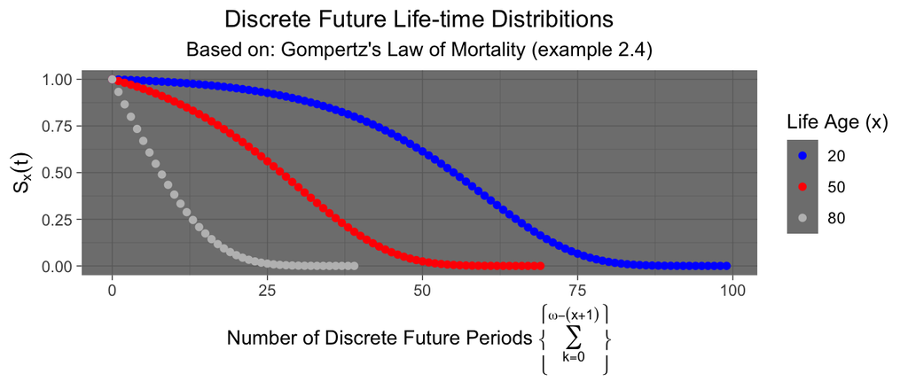

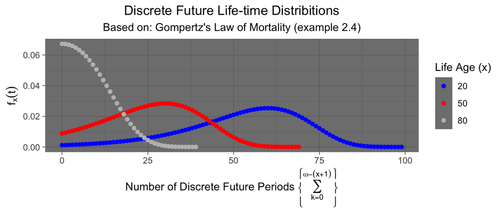

### §2.1.2: Complete Future Life-Time

This R code snippet calculates and visualizes the complete future lifetime distribution based on Gompertz’s Law of Mortality for ages ranging from 0 to 100 in increments of 10. Using the `discreteProbs` class, the code initializes mortality parameters $(B)$ and $(c)$ and sets the maximum age $(\omega)$ to 130. It iterates over the specified age list, computing the survival probabilities $_tp_x$ for each age, and accumulates these probabilities to calculate the complete future lifetime $e_x$ and the adjusted complete future lifetime $e^{o}_x$. The results are then compiled into a data frame and plotted using `ggplot2` to display the discrete complete future lifetime distribution. The plot is customized with titles, subtitles, and axis labels, and the final results are displayed both as a plot and a formatted table using `knitr::kable`.

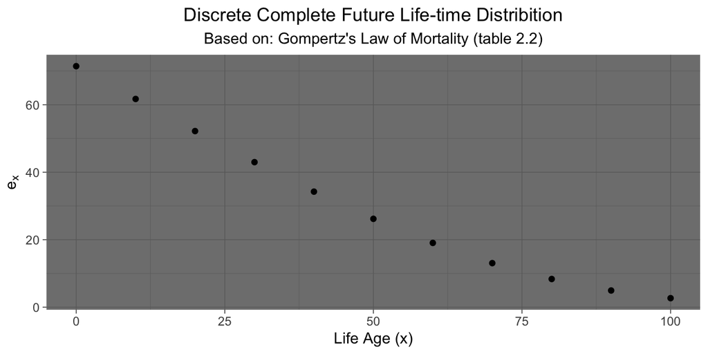

| age_x | e_x | e_o_x |
| --- | --- | --- |
| 0 | 71.437538 | 71.937538 |
| 10 | 61.722842 | 62.222842 |
| 20 | 52.202974 | 52.702974 |
| 30 | 42.992149 | 43.492149 |
| 40 | 34.251927 | 34.751927 |
| 50 | 26.191880 | 26.691880 |
| 60 | 19.051899 | 19.551899 |
| 70 | 13.057704 | 13.557704 |
| 80 | 8.354054 | 8.854054 |
| 90 | 4.943593 | 5.443593 |
| 100 | 2.673255 | 3.173255 |

## §2.2: Life-Tables

Life tables, derived from survival models, provide empirical data on mortality rates and survival probabilities at various ages. They are vital tools for actuaries, offering crucial insights that inform the creation and pricing of insurance policies and annuities by illustrating survival likelihoods across different age groups.

### §2.2.1: Select & Ultimate Life-Tables

| age+2 | l_x+2 | age_x | l_[x]+1 | l_[x] | 5_E_[x] | 10_E_[x] | 20_E_[x] |
| --- | --- | --- | --- | --- | --- | --- | --- |
| 20 | 100000.00 | 18 | NA | NA | NA | NA | NA |
| 21 | 99975.04 | 19 | NA | NA | NA | NA | NA |
| 22 | 99949.71 | 20 | 99973.75 | 99995.08 | 0.7825546 | 0.6122692 | 0.3744139 |
| 23 | 99923.98 | 21 | 99948.40 | 99970.04 | 0.7825367 | 0.6122293 | 0.3743102 |
| 24 | 99897.79 | 22 | 99922.65 | 99944.63 | 0.7825167 | 0.6121845 | 0.3741937 |
| 25 | 99871.08 | 23 | 99896.43 | 99918.81 | 0.7824941 | 0.6121342 | 0.3740628 |
| 26 | 99843.80 | 24 | 99869.70 | 99892.52 | 0.7824688 | 0.6120776 | 0.3739157 |
| 27 | 99815.86 | 25 | 99842.38 | 99865.69 | 0.7824403 | 0.6120140 | 0.3737505 |
| 28 | 99787.20 | 26 | 99814.41 | 99838.28 | 0.7824082 | 0.6119426 | 0.3735648 |
| 29 | 99757.71 | 27 | 99785.70 | 99810.20 | 0.7823722 | 0.6118623 | 0.3733562 |
| 30 | 99727.29 | 28 | 99756.17 | 99781.36 | 0.7823318 | 0.6117720 | 0.3731219 |
| 31 | 99695.83 | 29 | 99725.70 | 99751.69 | 0.7822863 | 0.6116706 | 0.3728588 |
| 32 | 99663.20 | 30 | 99694.18 | 99721.06 | 0.7822352 | 0.6115566 | 0.3725632 |
| 33 | 99629.26 | 31 | 99661.48 | 99689.36 | 0.7821777 | 0.6114285 | 0.3722313 |
| 34 | 99593.83 | 32 | 99627.47 | 99656.47 | 0.7821131 | 0.6112846 | 0.3718585 |
| 35 | 99556.75 | 33 | 99591.96 | 99622.23 | 0.7820406 | 0.6111228 | 0.3714400 |
| 36 | 99517.80 | 34 | 99554.78 | 99586.47 | 0.7819590 | 0.6109410 | 0.3709701 |
| 37 | 99476.75 | 35 | 99515.73 | 99549.01 | 0.7818673 | 0.6107368 | 0.3704427 |
| 67 | 93398.05 | 65 | 93989.16 | 94467.11 | 0.7554530 | 0.5537115 | 0.2441055 |
| 68 | 92706.06 | 66 | 93363.38 | 93895.00 | 0.7521413 | 0.5468165 | 0.2314308 |
| 69 | 91936.88 | 67 | 92667.50 | 93258.63 | 0.7484363 | 0.5391689 | 0.2179684 |
| 70 | 91082.43 | 68 | 91894.03 | 92551.02 | 0.7442937 | 0.5307006 | 0.2037691 |
| 71 | 90133.96 | 69 | 91034.84 | 91764.58 | 0.7396647 | 0.5213410 | 0.1889103 |
| 72 | 89082.09 | 70 | 90081.15 | 90891.07 | 0.7344961 | 0.5110176 | 0.1734984 |
| 73 | 87916.84 | 71 | 89023.56 | 89921.62 | 0.7287297 | 0.4996579 | 0.1576711 |
| 74 | 86627.64 | 72 | 87852.03 | 88846.72 | 0.7223023 | 0.4871908 | 0.1415981 |
| 75 | 85203.46 | 73 | 86555.99 | 87656.25 | 0.7151455 | 0.4735487 | 0.1254795 |
| 76 | 83632.89 | 74 | 85124.37 | 86339.55 | 0.7071859 | 0.4586704 | 0.1095418 |
| 77 | 81904.34 | 75 | 83545.75 | 84885.49 | 0.6983450 | 0.4425045 | 0.0940311 |
| 78 | 80006.23 | 76 | 81808.54 | 83282.61 | 0.6885397 | 0.4250131 | 0.0792030 |
| 79 | 77927.35 | 77 | 79901.17 | 81519.30 | 0.6776828 | 0.4061768 | 0.0653085 |
| 80 | 75657.16 | 78 | 77812.44 | 79584.04 | 0.6656839 | 0.3859994 | 0.0525787 |
| 81 | 73186.31 | 79 | 75531.88 | 77465.70 | 0.6524505 | 0.3645140 | 0.0412073 |
| 82 | 70507.19 | 80 | 73050.22 | 75153.97 | 0.6378899 | 0.3417887 | 0.0313340 |

## §2.3: Insurance Benefits

Insurance benefits are calculated by integrating survival probabilities to ensure adequate coverage. These benefits are based on empirical data from life tables, ensuring that payouts are financially viable and meet policyholders’ needs. Accurately determining the present values of future payouts is crucial for the sustainability of insurance products.

### §2.3.1: Discrete Insurance Benefits

This R code snippet continues the exploration of survival models by focusing on discrete insurance benefits. Building on earlier sections, it calculates and compares insurance benefits for various ages (30 to 32, 50 to 52, and 98 to 100) and monthly schedules (1, 4, 12, and 365 months). Using the `discreteProducts` class and an interest rate of 5%, it initializes product objects and computes whole life insurance benefit values for each age and monthly schedule. The results, showcasing insurance benefits for different age groups and schedules, are compiled into a data frame and presented as a comparison table using `knitr::kable`. This demonstrates the application of survival models to determine insurance benefits, highlighting their role in actuarial calculations and product development.

| age_x | A_x_(1) | A_x_(4) | A_x_(12) | A_x_(365) |
| --- | --- | --- | --- | --- |
| 30 | 0.0769828 | 0.0783982 | 0.0787172 | 0.0788721 |
| 31 | 0.0805419 | 0.0820227 | 0.0823565 | 0.0825185 |
| 32 | 0.0842693 | 0.0858186 | 0.0861678 | 0.0863374 |
| 50 | 0.1893079 | 0.1927898 | 0.1935745 | 0.1939553 |
| 51 | 0.1978038 | 0.2014422 | 0.2022621 | 0.2026601 |
| 52 | 0.2066380 | 0.2104392 | 0.2112957 | 0.2117114 |
| 98 | 0.8517747 | 0.8683882 | 0.8719789 | 0.8737015 |
| 99 | 0.8615266 | 0.8784388 | 0.8820775 | 0.8838209 |
| 100 | 0.8706841 | 0.8878989 | 0.8915840 | 0.8933472 |

### §2.3.2: M-thly Insurance Benefits

Expanding upon the previous sections on insurance benefits, this R code snippet focuses on m-thly insurance benefits. It calculates and compares insurance benefits for ages spanning from 20 to 21, 50 to 51, and 127 to 128, using a monthly schedule of 12 months, an interest rate of 5%, and an annuity schedule of ‘Due’. Utilizing the `discreteProducts` class, the code initializes product objects and computes probabilities $_tp_x$ and $_tq_x$ as well as whole-life insurance benefit values $A_x$ for each age. The results, illustrating insurance benefits for different age groups and monthly schedules, are organized into a data frame and presented as a comparison table using `knitr::kable`. This underscores the application of survival models in determining insurance benefits and underscores their significance in actuarial calculations and product evaluation.

| age_x | p_x_(12) | q_x_(12) | A_x_(12) |
| --- | --- | --- | --- |
| 20.00000 | 0.9999793 | 0.0000207 | 0.0503284 |
| 20.08333 | 0.9999793 | 0.0000207 | 0.0505138 |
| 20.16667 | 0.9999793 | 0.0000207 | 0.0507000 |
| 20.25000 | 0.9999793 | 0.0000207 | 0.0508869 |
| 20.33333 | 0.9999792 | 0.0000208 | 0.0510745 |
| 20.41667 | 0.9999792 | 0.0000208 | 0.0512629 |
| 20.50000 | 0.9999792 | 0.0000208 | 0.0514520 |
| 20.58333 | 0.9999792 | 0.0000208 | 0.0516419 |
| 20.66667 | 0.9999791 | 0.0000209 | 0.0518325 |
| 20.75000 | 0.9999791 | 0.0000209 | 0.0520239 |
| 20.83333 | 0.9999791 | 0.0000209 | 0.0522161 |
| 20.91667 | 0.9999791 | 0.0000209 | 0.0524090 |
| 21.00000 | 0.9999790 | 0.0000210 | 0.0526027 |
| 50.00000 | 0.9999036 | 0.0000964 | 0.1935745 |
| 50.08333 | 0.9999028 | 0.0000972 | 0.1942854 |
| 50.16667 | 0.9999020 | 0.0000980 | 0.1949987 |
| 50.25000 | 0.9999013 | 0.0000987 | 0.1957144 |
| 50.33333 | 0.9999005 | 0.0000995 | 0.1964324 |
| 50.41667 | 0.9998997 | 0.0001003 | 0.1971528 |
| 50.50000 | 0.9998989 | 0.0001011 | 0.1978756 |
| 50.58333 | 0.9998981 | 0.0001019 | 0.1986007 |
| 50.66667 | 0.9998972 | 0.0001028 | 0.1993282 |
| 50.75000 | 0.9998964 | 0.0001036 | 0.2000581 |
| 50.83333 | 0.9998956 | 0.0001044 | 0.2007904 |
| 50.91667 | 0.9998947 | 0.0001053 | 0.2015250 |
| 51.00000 | 0.9998939 | 0.0001061 | 0.2022621 |
| 127.00000 | 0.5308185 | 0.4691815 | 0.9914573 |
| 127.08333 | 0.5275379 | 0.4724621 | 0.9915161 |
| 127.16667 | 0.5242458 | 0.4757542 | 0.9915754 |
| 127.25000 | 0.5209423 | 0.4790577 | 0.9916360 |
| 127.33333 | 0.5176276 | 0.4823724 | 0.9916997 |
| 127.41667 | 0.5143019 | 0.4856981 | 0.9917701 |
| 127.50000 | 0.5109653 | 0.4890347 | 0.9918544 |
| 127.58333 | 0.5076180 | 0.4923820 | 0.9919669 |
| 127.66667 | 0.5042601 | 0.4957399 | 0.9921365 |
| 127.75000 | 0.5008920 | 0.4991080 | 0.9924217 |
| 127.83333 | 0.4975137 | 0.5024863 | 0.9929425 |
| 127.91667 | 0.4941254 | 0.5058746 | 0.9939456 |
| 128.00000 | 0.4907274 | 0.5092726 | 0.9959424 |

### §2.3.3: Mean & Variance of Insurance Benefit EPVs

Building upon the previous sections on insurance benefits, this R code snippet focuses on calculating the mean and standard deviation of insurance benefit EPVs (Equivalent Present Values). It considers m-thly schedules (1, 4, and 12), an interest rate of 5%, and an annuity schedule of ‘Due’. Age ranges from 20 to 100, with a benefit value $S$ set at $10^5$. The code initializes product objects for each m-thly variation using the `discreteProducts` class and computes the first and second moments of insurance benefit EPVs. It then calculates the mean and standard deviation using these moments. The results, demonstrating the mean and standard deviation for each age and m-thly schedule, are compiled into a data frame and presented as a comparison table using `knitr::kable`. This underscores the application of survival models in assessing the variability of insurance benefit EPVs and their significance in actuarial calculations and risk analysis.

| age_x | mean_A_x_(1) | mean_A_x_(4) | mean_A_x_(12) | std_x_(1) | std_x_(4) | std_x_(12) |
| --- | --- | --- | --- | --- | --- | --- |
| 20 | 4921.934 | 5012.444 | 5032.843 | 5810.199 | 5917.485 | 5941.594 |
| 40 | 12105.921 | 12328.500 | 12378.671 | 9389.205 | 9561.076 | 9599.940 |
| 60 | 29028.218 | 29562.687 | 29683.038 | 15516.790 | 15800.616 | 15864.829 |
| 80 | 59293.307 | 60394.389 | 60640.815 | 17254.507 | 17576.873 | 17648.706 |
| 100 | 87068.415 | 88789.887 | 89158.402 | 7860.275 | 8073.515 | 8110.447 |

### §2.3.4: Term Insurance Benefits

Expanding on the analysis of insurance benefits, this R code snippet focuses specifically on term insurance benefits. It calculates term insurance benefits for ages ranging from 20 to 100 and for term periods of 10 years. Utilizing m-thly schedules of 1, 4, and 12, an interest rate of 5%, and an annuity schedule of ‘Due’, the code initializes product objects for each m-thly variation using the `discreteProducts` class. It then computes term insurance benefits for each age and m-thly schedule. The results, illustrating term insurance benefits for different age groups and m-thly schedules, are compiled into a data frame and presented as a comparison table using `knitr::kable`. This demonstrates the application of survival models in determining term insurance benefits and underscores their importance in actuarial calculations and risk management.

| age_x | A_x´*10*(1) | A_x´*10*(4) | A_x´*10*(12) |
| --- | --- | --- | --- |
| 20 | 0.0020875 | 0.0021260 | 0.0021347 |
| 40 | 0.0057320 | 0.0058365 | 0.0058602 |
| 60 | 0.0425209 | 0.0432926 | 0.0434682 |
| 80 | 0.3372216 | 0.3434060 | 0.3448026 |
| 100 | 0.8694208 | 0.8866070 | 0.8902866 |

### §2.3.5: Endowment Insurance Benefits

This R code snippet delves into the analysis of endowment insurance benefits. It calculates endowment insurance benefits for ages ranging from 20 to 100 and for a term period of 10 years. Employing m-thly schedules of 1, 4, and 12, an interest rate of 5%, and an annuity schedule of ‘Due’, the code initializes product objects for each m-thly variation using the `discreteProducts` class. It then computes endowment insurance benefits for each age and m-thly schedule. The resulting benefits, representing different age groups and m-thly schedules, are compiled into a data frame and presented as a comparison table using `knitr::kable`. This highlights the application of survival models in determining endowment insurance benefits and underscores their significance in actuarial calculations and financial planning.

| age_x | A_x_10_(1) | A_x_10_(4) | A_x_10_(12) |
| --- | --- | --- | --- |
| 20 | 0.6143265 | 0.6143651 | 0.6143737 |
| 40 | 0.6149367 | 0.6150413 | 0.6150650 |
| 60 | 0.6211644 | 0.6219360 | 0.6221116 |
| 80 | 0.6767371 | 0.6829215 | 0.6843180 |
| 100 | 0.8707765 | 0.8879628 | 0.8916423 |

### §2.3.6: Ratios of Insurance Benefits

This R code snippet focuses on calculating the ratios of insurance benefits, providing insight into comparative benefit values. It computes these ratios for ages ranging from 20 to 120, considering different pairs of m-thly schedules. Using m-thly ratio schedules of (4, 1) and (12, 1), an interest rate of 5%, and an annuity schedule of ‘Due’, the code initializes product objects for both numerator and denominator distributions using the `discreteProducts` class. It then computes the insurance benefit ratios for each age and ratio schedule pair. The resulting ratios, indicating the relationship between benefit values for different m-thly schedules, are compiled into a data frame and presented as a comparison table using `knitr::kable`. This highlights the application of survival models in assessing and comparing insurance benefit values, offering valuable insights for actuarial analysis and product evaluation.

| age_x | A_x_(4) / A_x_(1) | A_x_(12) / A_x_(1) |
| --- | --- | --- |
| 20 | 1.018389 | 1.022534 |
| 40 | 1.018386 | 1.022530 |
| 60 | 1.018412 | 1.022558 |
| 80 | 1.018570 | 1.022726 |
| 100 | 1.019772 | 1.024004 |
| 120 | 1.029636 | 1.034607 |

## §2.4: Annuities

Annuities provide regular payments over the annuitant’s lifetime and rely heavily on survival models and life tables for valuation. Various types of annuities (immediate, deferred, fixed, and variable) require precise calculations of expected present values to ensure they provide sufficient income streams while remaining financially sustainable.

### §2.4.1: Whole-Life Annuities

This R code snippet focuses on calculating whole-life annuities, providing insights into annuity values across different m-thly schedules and annuity payment timings. It computes whole-life annuities for ages ranging from 20 to 100, considering m-thly schedules of 1, 4, and 12, and both ‘Due’ and ‘Immediate’ annuity schedules. The code initializes product objects for each combination of m-thly schedule and annuity schedule using the `discreteProducts` class. It then computes the whole-life annuity values for each age and schedule combination. The resulting annuity values, representing different age groups and payment timings, are compiled into a data frame and presented as a comparison table using `knitr::kable`. This highlights the application of survival models in assessing and comparing annuity values, offering valuable insights for actuarial analysis and financial planning.

| age_x | aD_x_(1) | aI_x_(1) | aD_x_(4) | aI_x_(4) | aD_x_(12) | aI_x_(12) |
| --- | --- | --- | --- | --- | --- | --- |
| 20 | 19.966394 | 18.966394 | 19.587563 | 19.337563 | 19.504002 | 19.420669 |
| 40 | 18.457757 | 17.457757 | 18.078905 | 17.828905 | 17.995344 | 17.912010 |
| 60 | 14.904074 | 13.904074 | 14.525011 | 14.275011 | 14.441437 | 14.358104 |
| 80 | 8.548406 | 7.548406 | 8.167148 | 7.917148 | 8.083443 | 8.000110 |
| 100 | 2.715633 | 1.715633 | 2.311659 | 2.061659 | 2.226607 | 2.143274 |

### §2.4.2: Term Annuities

This R code snippet focuses on calculating term annuities, offering insights into annuity values for specified term periods across different m-thly schedules and annuity payment timings. It computes term annuities for ages ranging from 20 to 100 and for a term period of 10 years. Considering m-thly schedules of 1 and 4, as well as both ‘Due’ and ‘Immediate’ annuity schedules, the code initializes product objects for each combination of m-thly schedule and annuity schedule using the `discreteProducts` class. It then computes the term annuity values for each age and schedule combination. The resulting annuity values, representing different age groups, term periods, and payment timings, are compiled into a data frame and presented as a comparison table using `knitr::kable`. This highlights the application of survival models in assessing and comparing annuity values over specific term periods, offering valuable insights for actuarial analysis and financial planning.

| age_x | aD_x´*10*(1) | aI_x´*10*(1) | aD_x´*10*(4) | aI_x´*10*(4) |
| --- | --- | --- | --- | --- |
| 20 | 8.099144 | 7.711383 | 7.952251 | 7.855311 |
| 40 | 8.086329 | 7.695533 | 7.938306 | 7.840607 |
| 60 | 7.955548 | 7.534192 | 7.796128 | 7.690789 |
| 80 | 6.788521 | 6.128036 | 6.538536 | 6.373415 |
| 100 | 2.713694 | 1.715049 | 2.310341 | 2.060680 |

### §2.4.3: Select & Ultimate Insurance Benefits and Annuities

This section delves into computing insurance benefits and annuity values, bridging select and ultimate periods while considering various advanced concepts in R programming. Initially, it establishes parameters such as m-thly schedules, interest rates, and annuity schedules, alongside age lists and terms. Employing the `discreteProducts` and `discreteProbs` classes, the code calculates insurance benefits and annuities, encompassing select and ultimate periods. Key advanced R concepts utilized include dynamic variable naming, conditional computation based on select periods, and recursive calculations to handle multiple select periods. By iteratively computing survival probabilities and benefit values, the snippet demonstrates sophisticated data manipulation techniques and showcases the integration of survival models into actuarial analysis. The resulting table presents a comprehensive overview of insurance benefits and annuities, offering valuable insights for actuarial assessments and financial planning strategies.

| age+2 | A_x+2 | a_x+2 | age_x | 2A_[x] | A_[x] | a_[x] |
| --- | --- | --- | --- | --- | --- | --- |
| 20 | 0.0492193 | 19.966394 | 18 | 0.0051492 | 0.0450338 | 20.054290 |
| 21 | 0.0514435 | 19.919686 | 19 | 0.0054387 | 0.0470553 | 20.011840 |
| 22 | 0.0537760 | 19.870704 | 20 | 0.0057551 | 0.0491755 | 19.967315 |
| 23 | 0.0562218 | 19.819342 | 21 | 0.0061007 | 0.0513991 | 19.920619 |
| 24 | 0.0587862 | 19.765489 | 22 | 0.0064781 | 0.0537309 | 19.871650 |
| 25 | 0.0614746 | 19.709033 | 23 | 0.0068903 | 0.0561761 | 19.820303 |
| 26 | 0.0642927 | 19.649852 | 24 | 0.0073401 | 0.0587397 | 19.766467 |
| 27 | 0.0672464 | 19.587826 | 25 | 0.0078310 | 0.0614272 | 19.710029 |
| 28 | 0.0703417 | 19.522824 | 26 | 0.0083665 | 0.0642443 | 19.650870 |
| 29 | 0.0735850 | 19.454715 | 27 | 0.0089505 | 0.0671968 | 19.588867 |
| 30 | 0.0769828 | 19.383361 | 28 | 0.0095871 | 0.0702909 | 19.523892 |
| 31 | 0.0805419 | 19.308620 | 29 | 0.0102810 | 0.0735327 | 19.455813 |
| 32 | 0.0842693 | 19.230344 | 30 | 0.0110369 | 0.0769289 | 19.384493 |
| 33 | 0.0881722 | 19.148383 | 31 | 0.0118600 | 0.0804862 | 19.309790 |
| 34 | 0.0922581 | 19.062580 | 32 | 0.0127561 | 0.0842115 | 19.231558 |
| 35 | 0.0965346 | 18.972774 | 33 | 0.0137312 | 0.0881121 | 19.149645 |
| 36 | 0.1010096 | 18.878799 | 34 | 0.0147918 | 0.0921954 | 19.063896 |
| 37 | 0.1056912 | 18.780485 | 35 | 0.0159450 | 0.0964690 | 18.974151 |
| 67 | 0.3831331 | 12.954204 | 65 | 0.1533320 | 0.3540744 | 13.564437 |
| 68 | 0.3978282 | 12.645607 | 66 | 0.1641099 | 0.3680148 | 13.271688 |
| 69 | 0.4128481 | 12.330190 | 67 | 0.1754813 | 0.3823009 | 12.971682 |
| 70 | 0.4281760 | 12.008304 | 68 | 0.1874577 | 0.3969203 | 12.664674 |
| 71 | 0.4437929 | 11.680350 | 69 | 0.2000480 | 0.4118586 | 12.350970 |
| 72 | 0.4596769 | 11.346785 | 70 | 0.2132581 | 0.4270987 | 12.030927 |
| 73 | 0.4758039 | 11.008118 | 71 | 0.2270907 | 0.4426214 | 11.704950 |
| 74 | 0.4921470 | 10.664912 | 72 | 0.2415447 | 0.4584047 | 11.373501 |
| 75 | 0.5086769 | 10.317785 | 73 | 0.2566152 | 0.4744242 | 11.037091 |
| 76 | 0.5253617 | 9.967405 | 74 | 0.2722929 | 0.4906529 | 10.696288 |
| 77 | 0.5421671 | 9.614491 | 75 | 0.2885639 | 0.5070614 | 10.351710 |
| 78 | 0.5590568 | 9.259808 | 76 | 0.3054092 | 0.5236179 | 10.004025 |
| 79 | 0.5759922 | 8.904164 | 77 | 0.3228049 | 0.5402880 | 9.653951 |
| 80 | 0.5929331 | 8.548406 | 78 | 0.3407217 | 0.5570357 | 9.302251 |
| 81 | 0.6098376 | 8.193410 | 79 | 0.3591249 | 0.5738225 | 8.949728 |
| 82 | 0.6266628 | 7.840081 | 80 | 0.3779744 | 0.5906085 | 8.597221 |

# §3: Remarks

## §3.1: Next Steps

The next steps of the research are geared towards achieving short and long-term goals outlined in the context of the proposal. In the short term, the focus is on interacting with potential user bases and collaborators to gather insights and feedback on the proposed methodologies and techniques. This interaction serves as a vital step in validating the relevance and applicability of the research to the actuarial community. Sharing initial findings with collaborators and stakeholders allows for iterative improvements and adjustments to align the work with the actual needs and challenges faced by actuarial practitioners.

In the long term, the research aims to translate its findings into tangible outcomes that benefit both the actuarial community and broader stakeholders. One key goal is the development of ExaminationAid® dashboards, which will serve as comprehensive tools for exam preparation, educational purposes, and professional development within the actuarial science field. Additionally, the research aims to disseminate its findings through publications, contributing valuable insights to the Actuarial Science CRAN community and academic discourse. By sharing work with the CRAN community, the research seeks to foster collaboration and innovation in actuarial modeling and data science applications. Moreover, the research aims to explore other avenues where the concepts and techniques developed can be applied, potentially expanding into related fields and industries beyond actuarial science. Through these long-term goals, the research aspires to make a lasting impact on actuarial education, practice, and research, driving advancements in the field and enhancing the capabilities of actuarial professionals worldwide.

# §4: Appendix

```
## #example 2.4: Gompertz survival model
## #-------------------------------------------------------------------------------code
## #discrete life ages
## age_list <- list(20,50,80)
## #mortality parameters
## B <- .0003; c <- 1.07
## #initialize discreteProbs object
## probFunc1 <- discreteProbs$new(
##   #age distribution range
##   age_range=list(0,120),
##   #mortality law
##   mort_law='Gompertz',
##   #mortality parameters
##   other_params=list(B,c))
## #initialize t_p_x plots
## tempPlot1 <- ggplot()
## #initialize t_f_x plots
## tempPlot2 <- ggplot()
## #create unique plots per life age (x)
## for(x in age_list){
##   #create data frame with desired probabilities...initialize future ages...max age of 120
##   tempData <- data.frame(age=c(0:(120-(x+1)))) %>%
##     #compute survival probability...t_p_x
##     mutate(p=sapply(age, probFunc1$p_x_t, x=x)) %>%
##     #compute future life-time pdf...t_f_x
##     mutate(f=sapply(age, probFunc1$f_x_t, x=x)) %>%
##     #assign age (x) indicator from age_list
##     mutate(age_x=factor(x))
##   #add computed values to plots
##   #plot t_p_x for age (x)
##   tempPlot1 <- tempPlot1 + geom_point(data=tempData, aes(age, p, colour=age_x))
##   #plot t_f_x for age (x)
##   tempPlot2 <- tempPlot2 + geom_point(data=tempData, aes(age, f, colour=age_x))
## }
## #customize plots
## #define color scheme for plot legend
## cols <- c("20" = "blue", "50" = "red", "80" = "grey")
## tempPlot1 <- tempPlot1 +
##              labs(
##                title='Discrete Future Life-time Distribitions',
```

[output cut: 8 more lines]

```
##              scale_colour_manual(values = cols)
## tempPlot2 <- tempPlot2 +
##              labs(
##                title='Discrete Future Life-time Distribitions',
##                x = TeX(r'(Number of Discrete Future Periods $\left{\sum_{k=0}^{\omega-(x+1)}\right}$)'),
##                y = TeX(r'($f_{x}(t)$)'),
##                subtitle = "Based on: Gompertz's Law of Mortality (example 2.4)",
##                color='Life Age (x)'
##              ) +
##              theme_dark() +
##              theme(plot.title = element_text(hjust = 0.5)) +
##              theme(plot.subtitle = element_text(hjust = 0.5)) +
##              scale_colour_manual(values = cols)
## #display plots
## print(tempPlot1); print(tempPlot2)
```

```
## #table 2.2: complete future life-time
## #-------------------------------------------------------------------------------code
## #desired ages
## age_list <- seq(0,100,10)
## #mortality parameters
## B <- .0003; c <- 1.07; omega <- 130
## #initialize discreteProbs object
## probFunc2 <- discreteProbs$new(
##   #age distribution range
##   age_range=list(0,omega),
##   #mortality law
##   mort_law='Gompertz',
##   #mortality parameters
##   other_params=list(B,c))
## #create base data frame with desired figures
## #initialize discrete list
## e_x_list <- list()
## #initialize continuous list
## e_o_x_list <- list()
## #perform iterations per age in input list
## for (x in age_list){
##   #setup distribution age range
##   table2_2_1 <- data.frame(age=c(1:(omega-(x+1)))) %>%
##     #compute t_p_x
##     mutate(p=sapply(age, probFunc2$p_x_t, x=x))
##   #compute and append e_x to e_x_list per x
##   e_x_list <- append(e_x_list,sum(table2_2_1$p))
##   #compute and append e_o_x to e_o_x_list per x
##   e_o_x_list <- append(e_o_x_list,(sum(table2_2_1$p)+0.5))
## }
## #plot results
## table2_2_2 <- data.frame(
##   #define table output...age_x || e_x || e_o_x
##   age_x = age_list,
##   e_x = unlist(e_x_list),
##   e_o_x = unlist(e_o_x_list)
## )
## plot2_2 <- ggplot(data=table2_2_2) +
##   geom_point(aes(x=age_x,y=e_x))+
##   labs(
##        title='Discrete Complete Future Life-time Distribition',
##        x = 'Life Age (x)',
##        y = TeX(r'($e_{x}$)'),
##        subtitle = "Based on: Gompertz's Law of Mortality (table 2.2)"
##      ) +
##    theme_dark() +
##    theme(plot.title = element_text(hjust = 0.5)) +
##    theme(plot.subtitle = element_text(hjust = 0.5)) +
##    scale_colour_manual(values = cols)
## print(plot2_2); knitr::kable(table2_2_2, align = "c")
```

```
## #table 3.1: ultimate life-table
## #-------------------------------------------------------------------------------code
## d <- 2; age_list <- list(20,110); i <- .05; v <- 1/(1+i)
## radix <- 10^5; terms <- c(5,10,20)
## probFunc3 <- discreteProbs$new()
## #create data frame with desired life-table values
## #define age range
## table_3_7_1 <- data.frame(age_x=c((age_list[[1]]-d):age_list[[2]])) %>%
##   #define ultimate period age
##   mutate(!!paste('age+',d,sep=''):=age_x+d) %>%
##   #define ultimate period life-table value
##   mutate(!!paste('l_x+',d,sep=''):=sapply(!!sym(paste('age+',d,sep='')),
##                                           probFunc3$lt_x_t,t=0,
##                                           radix=radix,
##                                           x0=age_list[[1]]))
##   for(select in c(1:d)){
##     #loop through periods
##     temp_name <- paste("p_[x]_",select,sep='')
##     #initialize survival feature name
##     table_3_7_1 <- table_3_7_1 %>%
##       #compute select period survival probabilities
##       mutate(!!temp_name:=sapply(age_x,probFunc3$select_p_x_t,t=select,d=d))
##     if (select > 1){ #setup period survival probabilities
##       #initialize survival feature name...select-1
##       previous_temp_name <- paste("p_[x]_",select-1,sep='')
##       #initialize survival feature name...select
##       current_temp_name <- paste("p_[x]_",select,sep='')
##       #initialize survival feature name...select-1
##       new_p_name <- paste("p_[x]+",select-1,"_1",sep='')
##       #initialize life-table feature name...select
##       new_l_name <- paste("l_[x]+",select-1,sep='')
##       table_3_7_1 <- table_3_7_1 %>%
##         #compute survival probabilities
##         mutate(!!new_p_name:= !!sym(current_temp_name) / !!sym(previous_temp_name)) %>%
##         #compute life-table values
##         mutate(!!new_l_name:= !!sym(paste('l_x+',d,sep=''))/!!sym(new_p_name))
##       table_3_7_1[1:d,new_l_name] <- NA
##     }
##     if (select == d){
##       #initialize life-table feature name
```

[output cut: 12 more lines]

```
##   }else if(term >= d){ #within ultimate period
##     temp_numerator <- paste('l_x+',d,sep='')
##     lag_level <- term - d
##   }
##   temp_denominator <- 'l_[x]'
##   temp_list <- list()
##   table_3_7_1 <- table_3_7_1 %>%
##     mutate(!!paste(term,'_E_[x]',sep=''):=(v^term)*lead(!!sym(temp_numerator),lag_level)/!!sym(temp_denominator))
##   }
## #query output
## table_3_7_2 <- table_3_7_1 %>%
##   #filter columns
##   select(c('age+2','l_x+2','age_x','l_[x]+1','l_[x]','5_E_[x]','10_E_[x]','20_E_[x]')) %>%
##   filter(age_x %in% c((age_list[[1]]-d):(age_list[[1]]+15),(80-15):80))
## knitr::kable(table_3_7_2, align = "c")
```

```
## #table 4.1: insurance benefits
## #-------------------------------------------------------------------------------code
## #define m_thly schedules
## m_list <- c(1,4,12,365)
## #define interest rate and annuity schedule
## i <- .05; annuity_schedule <- 'Due'
## #define age list
## age_list <- c(30:32,50:52,98:100)
## #initialize output table
## table_4_1_1 <- data.frame(age_x=age_list)
## for(m_th in m_list){
##   #initialize product object
##   tempPB <- discreteProducts$new(i=i,annuity_schedule=annuity_schedule,m=m_th)
##   table_4_1_1 <- table_4_1_1 %>%
##     #compute whole life insurance benefit values
##     mutate(!!paste('A_x_(',m_th,')',sep=''):=sapply(age_x,tempPB$whole_A_x,moment=1))
## }
## table_4_1_2 <- table_4_1_1 %>%
##   #filter columns
##   select(!contains('p'))
## knitr::kable(table_4_1_2, align = "c")
```

```
## #table 4.2: insurance benefits
## #-------------------------------------------------------------------------------code
## #define m_thly schedule, interest rate, and annuity schedule
## m_th <- 12; i <- .05; annuity_schedule <- 'Due'
## #define ages
## age_list <- c(seq(20,21,1/m_th),seq(50,51,1/m_th),seq(127,128,1/m_th))
## #define products class
## productFun1 <- discreteProducts$new(i=i,annuity_schedule=annuity_schedule,m=m_th)
## table_4_2_1 <- data.frame(age_x=age_list) %>%
##   #compute t_p_x
##   mutate('p_x_(12)'=sapply(age_x,productFun1$p_x_t,t=1)) %>%
##   #compute t_q_x
##   mutate('q_x_(12)'=sapply(age_x,productFun1$q_x_t,t=1)) %>%
##   #compute whole-life probability
##   mutate('A_x_(12)'=sapply(age_x,productFun1$whole_A_x,moment=1))
## knitr::kable(table_4_2_1, align = "c")
```

```
## #table 4.3: mean and standard deviation of insurance benefit EPV
## #-------------------------------------------------------------------------------code
## #define m_thly schedules, interest rate, and annuity schedule
## m_list <- c(1,4,12); i <- .05; annuity_schedule <- 'Due'
## #define ages and benefit value
## age_list <- seq(20,100,20); S <- 10^5
## #initialize output table
## table_4_3_1 <- data.frame(age_x=age_list)
## for(m_th in m_list){
##   #define case product object...m_th variation
##   productFun2 <- discreteProducts$new(i=i,annuity_schedule=annuity_schedule,m=m_th)
##    table_4_3_1 <- table_4_3_1 %>%
##     #compute first moment
##     mutate(!!paste('A_x_(',m_th,')',sep=''):=sapply(age_x,productFun2$whole_A_x,moment=1)) %>%
##     #compute second moment
##     mutate(!!paste('2_A_x_(',m_th,')',sep=''):=sapply(age_x,productFun2$whole_A_x,moment=2)) %>%
##     #compute mean
##     mutate(!!paste('mean_A_x_(',m_th,')',sep=''):=S*!!sym(paste('A_x_(',m_th,')',sep=''))) %>%
##     #compute standard deviation
##     mutate(!!paste('std_x_(',m_th,')',sep=''):=S*sqrt(!!sym(paste('2_A_x_(',m_th,')',sep=''))-
##                                                         (!!sym(paste('A_x_(',m_th,')',sep=''))*
##                                                            !!sym(paste('A_x_(',m_th,')',sep='')))))
## }
## table_4_3_2 <- table_4_3_1 %>%
##   #collect age, mean, and std columns
##   select(contains(c('age','mean','std')))
## knitr::kable(table_4_3_2, align = "c")
```

```
## #table 4.4: term insurance benefits
## #-------------------------------------------------------------------------------code
## #define m_thly schedules, interest rate, and annuity schedule
## m_list <- c(1,4,12); i <- .05; annuity_schedule <- 'Due'
## #define ages and term period
## age_list <- seq(20,100,20); term <- 10
## #initialize output table
## table_4_4_1 <- data.frame(age_x=age_list)
## for(m_th in m_list){
##   #define case product object...m_th variation
##   productFun3 <- discreteProducts$new(i=i,annuity_schedule=annuity_schedule,m=m_th)
##   table_4_4_1 <- table_4_4_1 %>%
##     #compute term insurance benefit
##     mutate(!!paste('A_x´_',term,'_(',m_th,')',sep=''):=sapply(age_x,productFun3$term_A_x,moment=1,n=term))
## }
## knitr::kable(table_4_4_1, align = "c")
```

```
## #table 4.5: endowment insurance benefits
## #-------------------------------------------------------------------------------code
## #define m_thly schedules, interest rate, and annuity schedule
## m_list <- c(1,4,12); i <- .05; annuity_schedule <- 'Due'
## #define ages and term period
## age_list <- seq(20,100,20); term <- 10
## #initialize output table
## table_4_5_1 <- data.frame(age_x=age_list)
## for(m_th in m_list){
##   #define case product object...m_th variation
##   productFun4 <- discreteProducts$new(i=i,annuity_schedule=annuity_schedule,m=m_th)
##   table_4_5_1 <- table_4_5_1 %>%
##     #compute endowment insurance benefit
##     mutate(!!paste('A_x_',term,'_(',m_th,')',sep=''):=sapply(age_x,productFun4$endowment_A_x,moment=1,n=term))
## }
## knitr::kable(table_4_5_1, align = "c")
```

```
## #table 4.6: ratios of insurance benefits
## #-------------------------------------------------------------------------------code
## #define m_thly ratio schedules, interest rate, and annuity schedule
## ratio_mth <- list(c(4,1),c(12,1)); i <- .05; annuity_schedule <- 'Due'
## #define ages
## age_list <- seq(20,120,20)
## #initialize output table
## table_4_6_1 <- data.frame(age_x=age_list)
## #define case product object...m_th variation
## for(m_th in ratio_mth){
##   #initialize numerator product distribution
##   productFun5 <- discreteProducts$new(i=i,annuity_schedule=annuity_schedule,m=m_th[[1]])
##   #initialize denominator product distribution
##   productFun6 <- discreteProducts$new(i=i,annuity_schedule=annuity_schedule,m=m_th[[2]])
##   #append computations to initialized output table
##   table_4_6_1 <- table_4_6_1 %>%
##     #compute insurance benefit ratios
##     mutate(!!paste('A_x_(',m_th[[1]],') / A_x_(',m_th[[2]],')',sep='') := sapply(age_x,
##                                                                                  productFun5$whole_A_x,
##                                                                                  moment=1)/
##                                                                             sapply(age_x,
##                                                                                    productFun6$whole_A_x,
##                                                                                    moment=1))
## }
## knitr::kable(table_4_6_1, align = "c")
```

```
## #table 5.1: whole-life annuities
## #-------------------------------------------------------------------------------code
## #define m_thly schedules, interest rate, and annuity schedules
## m_list <- c(1,4,12); i <- .05; annuity_schedules <- c('Due','Immediate')
## #define ages
## age_list <- seq(20,100,20)
## #initialize output table
## table_5_1_1 <- data.frame(age_x=age_list)
## for(m_th in m_list){ #m-thly variation
##   for(schedule in annuity_schedules){ #annuity schedule variation
##     #define case product object...m_th and schedule variation
##     productFun7 <- discreteProducts$new(i=i,annuity_schedule=schedule,m=m_th)
##     table_5_1_1 <- table_5_1_1 %>%
##       #compute whole-life annuity values
##       mutate(!!paste('a',substr(schedule,1,1),'_x_(',m_th,')',sep=''):=sapply(age_x,
##                                                                               productFun7$whole_a_x))
## }}
## knitr::kable(table_5_1_1, align = "c")
```

```
## #table 5.2: term annuities
## #-------------------------------------------------------------------------------code
## #define m_thly schedules, interest rate, and annuity schedules
## m_list <- c(1,4); i <- .05; annuity_schedules <- c('Due','Immediate')
## #define ages and term period
## age_list <- seq(20,100,20); term <- 10
## #initialize output table
## table_5_2_1 <- data.frame(age_x=age_list)
## for(m_th in m_list){ #m-thly variation
##   for(schedule in annuity_schedules){ #annuity schedule variation
##     #define case product object...m_th and schedule variation
##     productFun8 <- discreteProducts$new(i=i,annuity_schedule=schedule,m=m_th)
##     table_5_2_1 <- table_5_2_1 %>%
##       #compute term annuity values
##       mutate(!!paste('a',substr(schedule,1,1),'_x´_',term,'_(',m_th,')',sep=''):=sapply(age_x,
##                                                                                         productFun8$term_a_x,
##                                                                                         n=term))
## }}
## knitr::kable(table_5_2_1, align = "c")
```

```
## #table 5.3: insurance benefits and annuity values
## #-------------------------------------------------------------------------------code
## d <- 2; age_list <- list(20,80); i <- .05; v <- 1/(1+i) #compute annual discount rate
## S <- 10^5; terms <- c(5,10,20)
## productFun9 <- discreteProducts$new()
## probFunc4 <- discreteProbs$new()
## #create data frame with desired life-table values
## #define age range
## table_5_3_1 <- data.frame(age_x=c((age_list[[1]]-d):(age_list[[1]]+15),
##                                   (age_list[[2]]-15):age_list[[2]])) %>%
##   #define ultimate period age
##   mutate(!!paste('age+',d,sep=''):=age_x+d)  %>%
##   #define ultimate period life-table value
##   #first-moment insurance benefit value
##   mutate(!!paste('A_x+',d,sep=''):=sapply(!!sym(paste('age+',d,sep='')),
##                                           productFun9$whole_A_x,
##                                           moment=1)) %>%
##   #second-moment insurance benefit value
##   mutate(!!paste('2A_x+',d,sep=''):=sapply(!!sym(paste('age+',d,sep='')),
##                                            productFun9$whole_A_x,
##                                            moment=2)) %>%
##   #annuity value
##   mutate(!!paste('a_x+',d,sep=''):=sapply(!!sym(paste('age+',d,sep='')),
##                                           productFun9$whole_a_x))
##   #compute helper columns and products value
##   for(select in c(1:d)){
##     #loop through periods
##     temp_name <- paste("p_[x]_",select,sep='')
##     #initialize survival feature name
##     table_5_3_1 <- table_5_3_1 %>%
##       #compute select period survival probabilities
##       mutate(!!temp_name:=sapply(age_x,
##                                  probFunc4$select_p_x_t,
##                                  t=select,
##                                  d=d))
##     if (select > 1){ #setup period survival probabilities
##       #initialize survival feature name...select-1
##       previous_temp_name <- paste("p_[x]_",select-1,sep='')
##       #initialize survival feature name...select
##       current_temp_name <- paste("p_[x]_",select,sep='')
```

[output cut: 84 more lines]

```
##           #compute first-moment annuity values
##           mutate(!!current_a_name := 1+(v*!!sym(current_p_name)*!!sym(previous_a_name))) %>%
##           #compute first-moment annuity values
##           mutate(!!new_a_name := 1+(v*!!sym(new_p_name)*!!sym(current_a_name))) %>%
##           #compute second-moment benefit values
##           mutate(!!current_2A_name := ((v^2)*(1-!!sym(current_p_name)))+((v^2)*!!sym(current_p_name)*
##                                                                            !!sym(previous_2A_name))) %>%
##           #compute second-moment benefit values
##           mutate(!!new_2A_name := ((v^2)*(1-!!sym(new_p_name)))+((v^2)*!!sym(new_p_name)*
##                                                                    !!sym(current_2A_name)))}}}}
## #query output
## table_5_3_2 <- table_5_3_1 %>%
##   #filter columns
##   select(c('age+2','A_x+2','a_x+2','age_x','2A_[x]','A_[x]','a_[x]'))
## knitr::kable(table_5_3_2, align = "c")
```

# §5: References

```
## Dutang C, Goulet V (2024). _ CRAN Task View: Actuarial Science_.
## <https://CRAN.R-project.org/view=ActuarialScience>.
```

```
## C.Dickson D, Hardy MR, Waters HR (2020). _Actuarial Mathematics for
## Life Contingent Risks_. Cambridge University Press, Cambridge. ISBN
## 9781108478083, <www.cambridge.org/isas>.
```

```
## Wickham H (2019). _Advanced R_. Chapman and Hall/CRC. ISBN
## 9780815384571, <https://adv-r.hadley.nz/#welcome>.
```